# Curs de manipulació de dades en R

24 de juliol de 2025

## Què és l’estadística?

## Parts

### Estadística descriptiva

### Tests d’hipòtesi

### Models predictius

## Estadística descriptiva

## Descriure les variables de l’estudi.

Aquestes poden ser: - Categòriques - Numèriques

Les podem donar: - Soles (la mitjana d’edat de la mostra és de 70 anys). - Creuades (la mitjana d’edat de tractats és de 45 i la de no tractats de 60).

## Variables categòriques

| Tipus | Dades | Gràfics |
| --- | --- | --- |
| Soles | Percentatges | De barres |
| Creuades | Percentatges | De barres aparellats |
| Creuades | Taules de contingència | De mosaic |

## Exemples dades

```r
prop.table(table(df$Gender)) * 100
```

```
##
##   Female     Male
## 24.35678 75.64322
```

```r
prop.table(table(df$Gender, df$Malaltia)) * 100
```

```
##
##             Malalt No malalt
##   Female  8.576329 15.780446
##   Male   20.068611 55.574614
```

## Funcions útils

```r
gmodels::CrossTable(df$Gender, df$Malaltia, chisq = T, fisher = T)
```

```
##
##
##    Cell Contents
## |-------------------------|
## |                       N |
## | Chi-square contribution |
## |           N / Row Total |
## |           N / Col Total |
## |         N / Table Total |
## |-------------------------|
##
##
## Total Observations in Table:  583
##
##
##              | df$Malaltia
##    df$Gender |    Malalt | No malalt | Row Total |
## -------------|-----------|-----------|-----------|
##       Female |        50 |        92 |       142 |
##              |     2.137 |     0.858 |           |
##              |     0.352 |     0.648 |     0.244 |
##              |     0.299 |     0.221 |           |
##              |     0.086 |     0.158 |           |
## -------------|-----------|-----------|-----------|
##         Male |       117 |       324 |       441 |
##              |     0.688 |     0.276 |           |
##              |     0.265 |     0.735 |     0.756 |
##              |     0.701 |     0.779 |           |
##              |     0.201 |     0.556 |           |
## -------------|-----------|-----------|-----------|
## Column Total |       167 |       416 |       583 |
##              |     0.286 |     0.714 |           |
## -------------|-----------|-----------|-----------|
##
##
## Statistics for All Table Factors
##
##
## Pearson's Chi-squared test
## ------------------------------------------------------------
```

[output cut: 10 more lines]

```
##
## Alternative hypothesis: true odds ratio is not equal to 1
## p =  0.05460083
## 95% confidence interval:  0.9805246 2.293142
##
## Alternative hypothesis: true odds ratio is less than 1
## p =  0.9809783
## 95% confidence interval:  0 2.150847
##
## Alternative hypothesis: true odds ratio is greater than 1
## p =  0.03100023
## 95% confidence interval:  1.047549 Inf
##
##
##
```

## Exemples gràfics - Variable sola

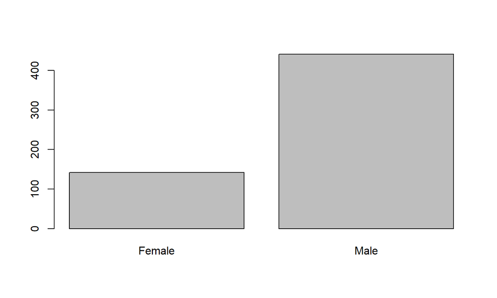

```r
plot(df$Gender)
```

## Exemples gràfics - Variables creuades

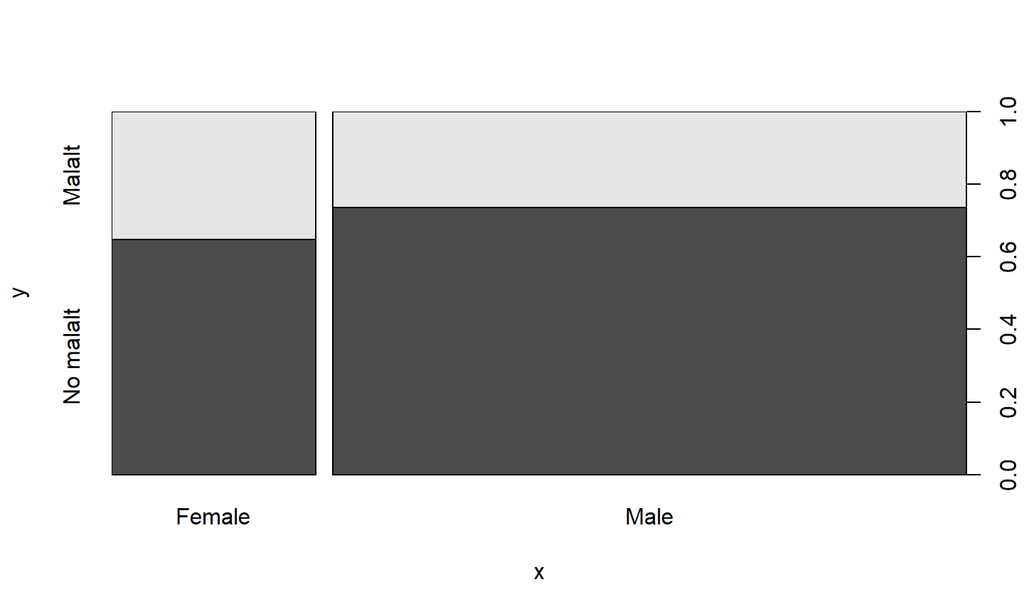

```r
plot(df$Gender, df$Malaltia)
```

## Exemples gràfics

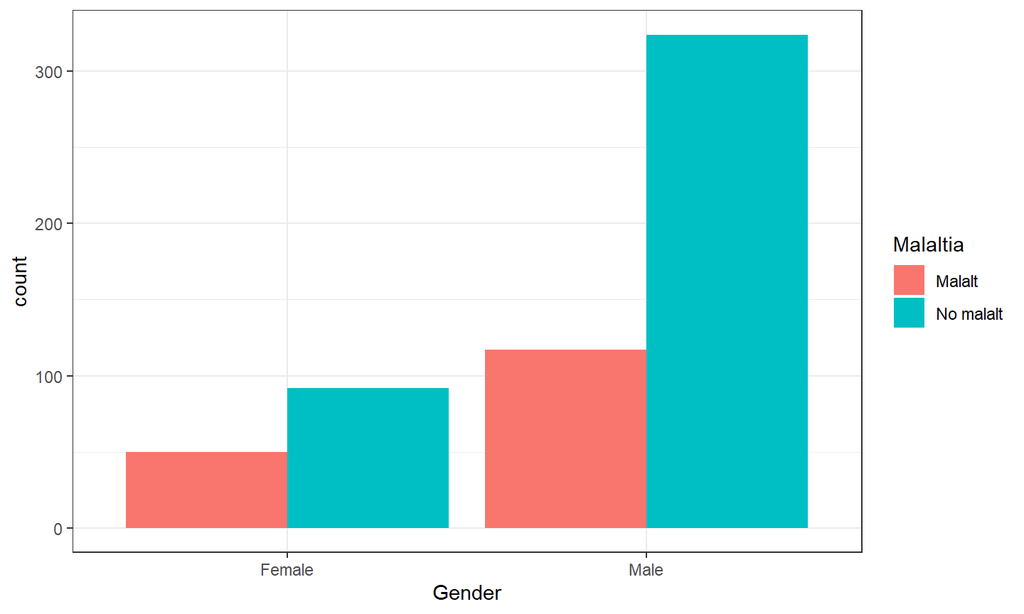

```r
ggplot(df, aes(x = Gender, fill = Malaltia)) +
  geom_bar(stat = "count", position = "dodge")
```

## Exemples gràfics

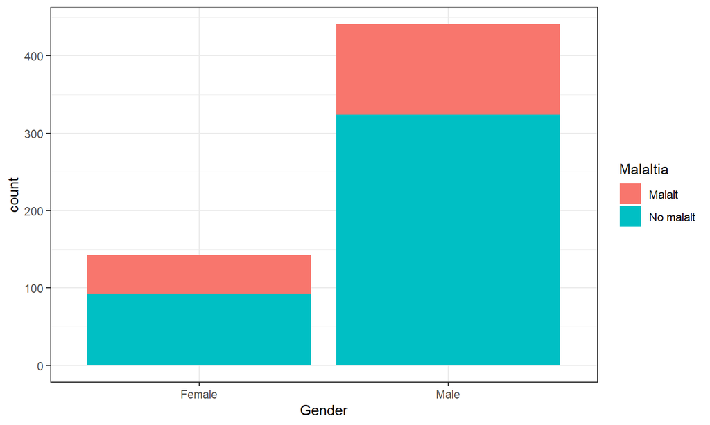

```r
ggplot(df, aes(x = Gender, fill = Malaltia)) +
  geom_bar(stat = "count", position = "stack")
```

## Variables contínues

| Tipus | Dades | Gràfics |
| --- | --- | --- |
| Soles - Normals | Mitjana i desviació estàndard | Histograma o boxplot |
| Soles - No normals | Mediana i quartils | Histograma o boxplot |
| Creuada amb una categòrica | Mitjanes / Medianes dels grups | Boxplots o Violinplots |
| Creuada amb una contínua | Correlació | Gràfic de punts |

## Exemples dades

```r
shapiro.test(df$Total_Bilirubin)
```

```
##
##  Shapiro-Wilk normality test
##
## data:  df$Total_Bilirubin
## W = 0.45977, p-value < 2.2e-16
```

No és normal, per tant:

```r
summary(df$Total_Bilirubin)
```

```
##    Min. 1st Qu.  Median    Mean 3rd Qu.    Max.
##   0.400   0.800   1.000   3.299   2.600  75.000
```

## Exemples dades

```r
psych::describeBy(df$Total_Bilirubin, df$Gender)
```

```
##
##  Descriptive statistics by group
## group: Female
##    vars   n mean   sd median trimmed  mad min  max range skew kurtosis   se
## X1    1 142 2.32 4.86    0.8    1.04 0.15 0.5 27.7  27.2  3.9    14.89 0.41
## ------------------------------------------------------------
## group: Male
##    vars   n mean   sd median trimmed  mad min max range skew kurtosis   se
## X1    1 441 3.61 6.56    1.2    2.01 0.74 0.4  75  74.6  4.9    36.75 0.31
```

## Exemples gràfics - Variables soles

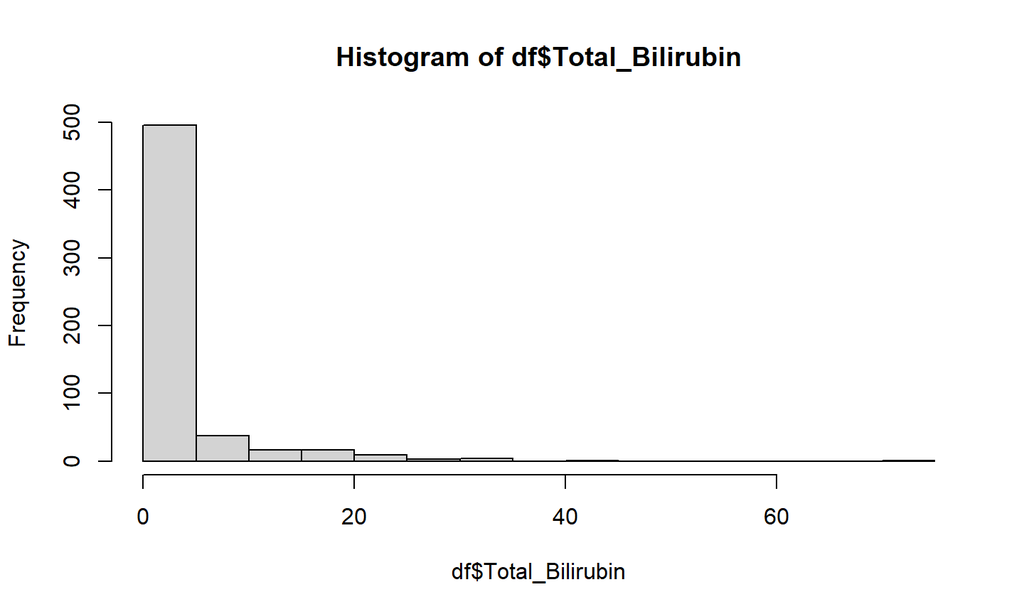

```r
hist(df$Total_Bilirubin)
```

## Exemples gràfics - Variables creuades amb categòrica

Veieu que plot ja tria automàticament el tipus de gràfic!

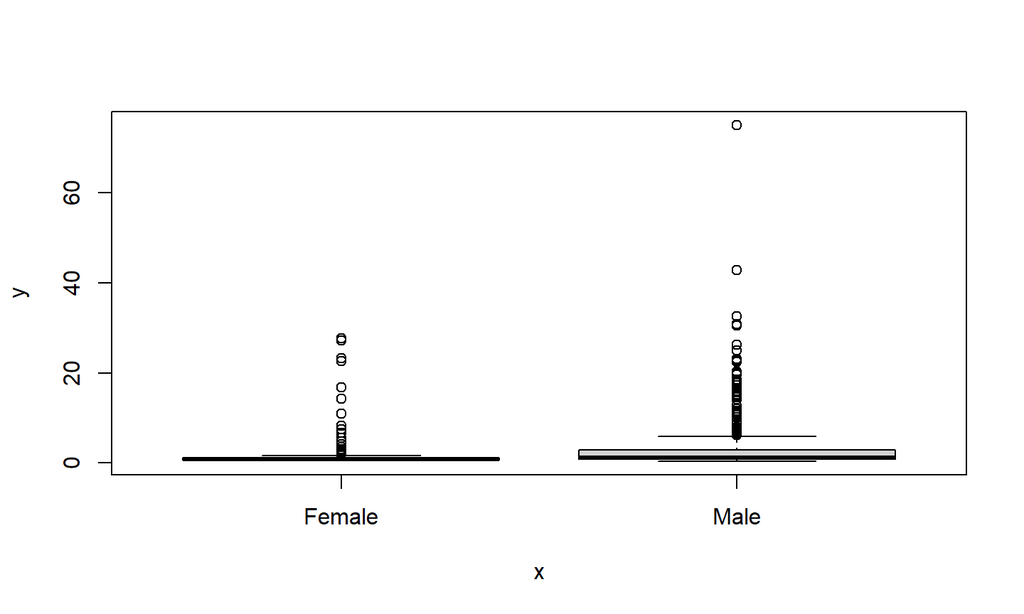

```r
plot(df$Gender, df$Total_Bilirubin)
```

## Exemples gràfics - Variables creuades

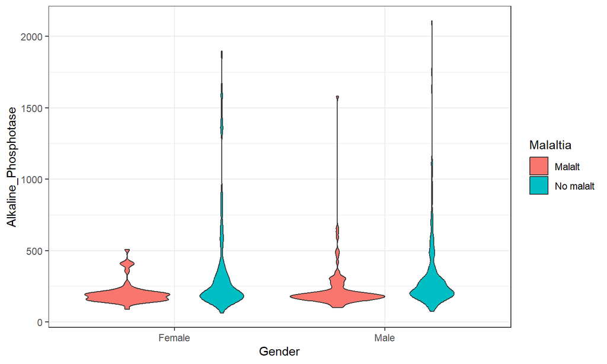

```r
library(ggplot2)
ggplot(df, aes(x = Gender, y = Alkaline_Phosphotase, fill = Malaltia)) +
  geom_violin()
```

## Exemples gràfics - Variables creuades amb contínua

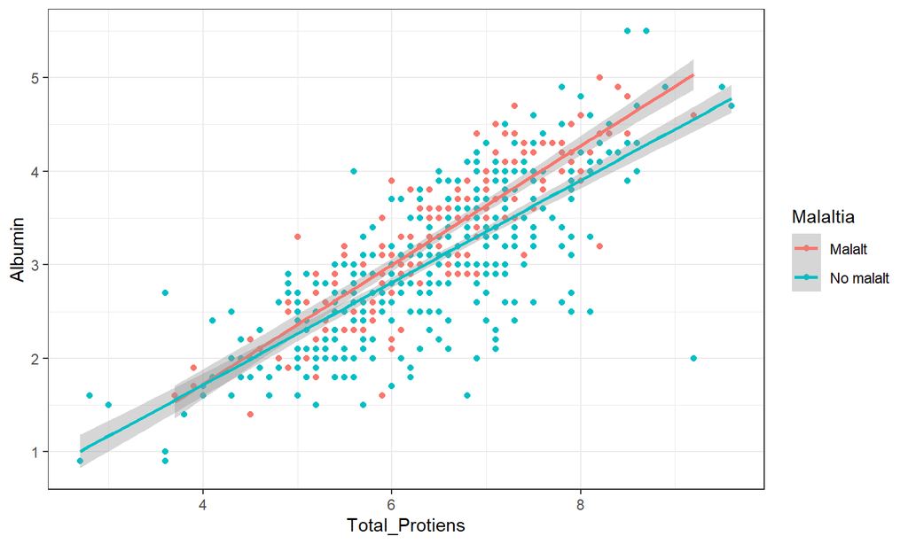

```r
library(ggplot2)
ggplot(df, aes(x = Total_Protiens, y = Albumin, colour = Malaltia)) +
  geom_point() +
  geom_smooth(method = "lm")
```

## Tot a la vegada: taula descriptiva

Paquet CompareGroups

```r
library(compareGroups)
res <- compareGroups(Malaltia ~ ., data = df, method = 4)
restab <- createTable(res)
export2md(restab, format = "html")
```

Summary descriptives table by groups of `Malaltia’

|  | Malalt | No malalt | p.overall |
| --- | --- | --- | --- |
|  | N=167 | N=416 |  |
| Age | 40.0 [28.0;55.0] | 46.0 [34.0;58.0] | 0.002 |
| Gender: |  |  | 0.060 |
| Female | 50 (29.9%) | 92 (22.1%) |  |
| Male | 117 (70.1%) | 324 (77.9%) |  |
| Total_Bilirubin | 0.80 [0.70;1.10] | 1.40 [0.80;3.62] | <0.001 |
| Direct_Bilirubin | 0.20 [0.20;0.35] | 0.50 [0.20;1.80] | <0.001 |
| Alkaline_Phosphotase | 186 [162;213] | 229 [186;315] | <0.001 |
| Alamine_Aminotransferase | 27.0 [20.0;37.5] | 41.0 [25.0;76.5] | <0.001 |
| Aspartate_Aminotransferase | 29.0 [21.0;43.5] | 52.5 [29.8;109] | <0.001 |
| Total_Protiens | 6.60 [5.90;7.30] | 6.55 [5.70;7.20] | 0.437 |
| Albumin | 3.40 [2.90;4.00] | 3.00 [2.50;3.62] | <0.001 |
| Albumin_and_Globulin_Ratio | 1.00 [0.90;1.20] | 0.90 [0.70;1.10] | <0.001 |

## Tot a la vegada: gràfics

```r
GGally::ggpairs(df)
```

[output not shown]

## Interludi: transformació de variables

```r
df |>
  mutate(
    Total_Protiens = log(Total_Protiens),
    Albumin = log(Albumin),
    # etc.
  )
```

**NOTA:** compte perquè el logaritme de 0 és -Inf! Assegureu-vos que no tenim valors iguals o més petits que 0 abans de fer el logaritme.

## Transforamació de variables: gràficament

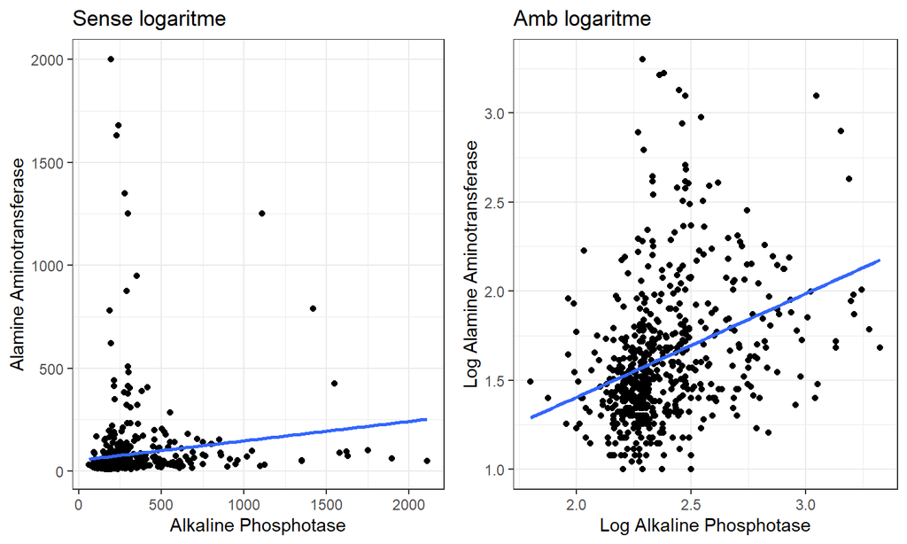

## Tests d’hipòtesi

## Hipòtesis

### **Hipòtesi de treball** o hipòtesi alternativa (\(H_1\))

És la hipòtesi de l’estudi, la que volem “demostrar”.

Exemple: hi ha més contaminació a Tarragona que a Reus.

### **Hipòtesi nul·la** (\(H_0\))

És la contrària a la d’estudi. Ens permet descartar o no la d’estudi.

Exemple: Reus està igual o més de contaminat que Tarragona.

## Variables

**Variable independent:** la variable de base, la que no depèn de l’altra.

Exemple: municipi (Reus o Tarragona).

**Variable dependent:** la variable d’interès, que volem saber si depèn (o està associada) amb la independent.

Exemple: nivell de contaminació.

## Exemple: gràficament

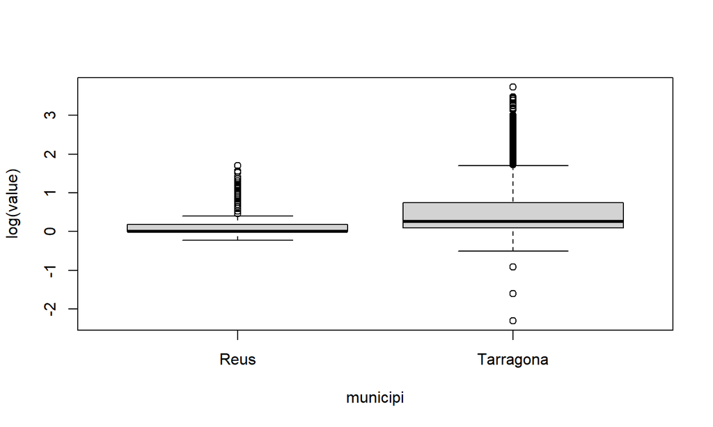

```r
library(tidyr)
loc <- readr::locale(encoding = "latin1")
cont <- readr::read_csv("data/contaminacio.csv", locale = loc) %>%
  pivot_longer(starts_with("h")) %>%
  select(data, contaminant, municipi, name, value) %>%
  mutate(municipi = as.factor(municipi)) %>%
  drop_na()
plot(log(value) ~ municipi, cont %>% filter(contaminant == "H2S"))
```

Sembla que a Tarragona hi ha més H2S. Però és significatiu o és l’atzar?

## Nivell de confiança i p-valor

> Quines probabilitats hi ha de trobar les nostres dades donat que la hipòtesi nul·la (\(H_0\)) és certa?

És a dir, quines probabilitats hi ha de que el que hagi vist sigui a causa de l’atzar?

Aquesta probabilitat mai és 0, així que he d’establir un nivell de confiança (normalment el 95%). Això vol dir que si calculo que les probabilitats de que la hipòtesi nul·la sigui certa donades les meves dades són de menys del 5%, la *rebutjaré* i *acceptaré* l’alternativa.

Aquesta probabilitat és el **p-valor**.

## Tests d’hipòtesi

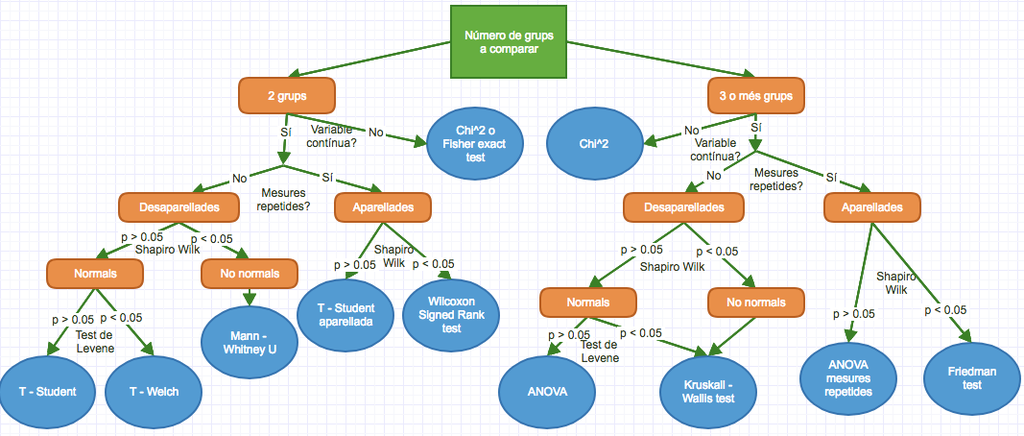

## En R

| Test | Comanda 1 | Comanda 2 |
| --- | --- | --- |
| Chi 2 | chisq.test(x, y) |  |
| Fisher exact test | fisher.test(x, y) |  |
| Shapiro Wilk | shapiro.test(x) |  |
| Levene | var.test(x, y) | levene.test(y, group) |
| T - Student | t.test(x, y, var.equal = TRUE) | t.test(formula, data, var.equal = TRUE) |
| T - Welch | t.test(x, y) | t.test(formula, data) |
| Mann-Whitney U | wilcox.test(x, y) | wilcox.test(formula, data) |

## En R (continuació)

[output not shown]

## Exemple: contaminació

Tenim una variable independent categòrica amb dos factors (municipi amb Reus i Tarragona) i una variable dependent contínua.

Primer mirem si la variable és normal amb el test de shapiro.wilk:

```r
shapiro.test(cont$value)
```

```
## Error in shapiro.test(cont$value): sample size must be between 3 and 5000
```

Vaja… Agafem doncs només les 5000 primeres entrades:

```r
shapiro.test(cont$value[1:5000])
```

```
##
##  Shapiro-Wilk normality test
##
## data:  cont$value[1:5000]
## W = 0.65004, p-value < 2.2e-16
```

Com que el p-valor és més petit de 0.05 i la hipòtesi nul·la del test de shapiro és que la variable és normaml, diem que **no** és normal.

## Exemple: contaminació

Per tant, fem test U de Mann Whitney, en R:

```r
wilcox.test(value ~ municipi, cont)
```

```
##
##  Wilcoxon rank sum test with continuity correction
##
## data:  value by municipi
## W = 9614526855, p-value < 2.2e-16
## alternative hypothesis: true location shift is not equal to 0
```

## Exemple: supervivència al Titanic

Carreguem i preparem les dades del Titanic:

```r
# install.packages("titanic") # Descomenta si no el tens
library(titanic)
library(dplyr)
library(ggplot2)

df <- titanic_train |>
  mutate(
    Survived = factor(Survived, levels = c(0, 1), labels = c("No", "Sí")),
    Sex = factor(Sex),
    Pclass = factor(Pclass)
  ) |>
  select(Survived, Sex, Age, Fare, Pclass) |>
  drop_na(Age, Fare)
```

## 1. Supervivència segons edat

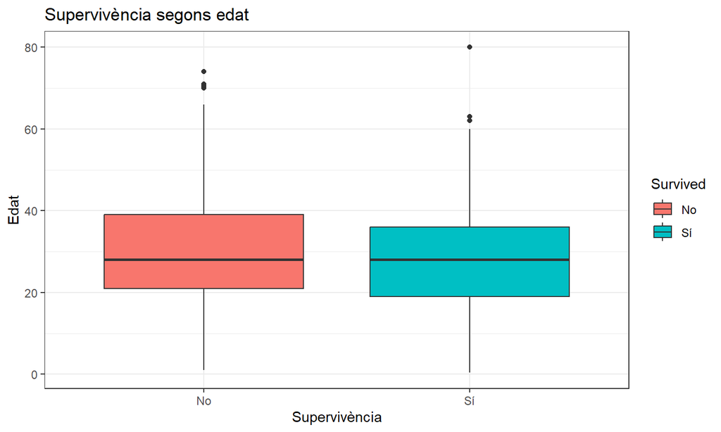

```r
ggplot(df, aes(x = Survived, y = Age, fill = Survived)) +
  geom_boxplot() +
  labs(title = "Supervivència segons edat", x = "Supervivència", y = "Edat")
```

## 1. T-test

```r
t.test(Age ~ Survived, data = df)
```

```
##
##  Welch Two Sample t-test
##
## data:  Age by Survived
## t = 2.046, df = 598.84, p-value = 0.04119
## alternative hypothesis: true difference in means between group No and group Sí is not equal to 0
## 95 percent confidence interval:
##  0.09158472 4.47339446
## sample estimates:
## mean in group No mean in group Sí
##         30.62618         28.34369
```

## 2. Supervivència segons preu del bitllet

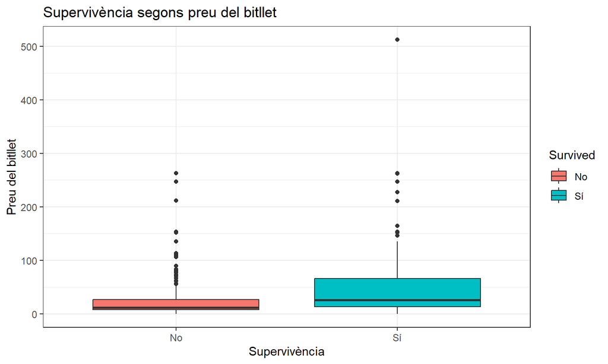

```r
ggplot(df, aes(x = Survived, y = Fare, fill = Survived)) +
  geom_boxplot() +
  labs(title = "Supervivència segons preu del bitllet", x = "Supervivència", y = "Preu del bitllet")
```

## 2. Mann-Whitney U

```r
wilcox.test(Fare ~ Survived, data = df)
```

```
##
##  Wilcoxon rank sum test with continuity correction
##
## data:  Fare by Survived
## W = 36983, p-value < 2.2e-16
## alternative hypothesis: true location shift is not equal to 0
```

## 3. Sexe i supervivència

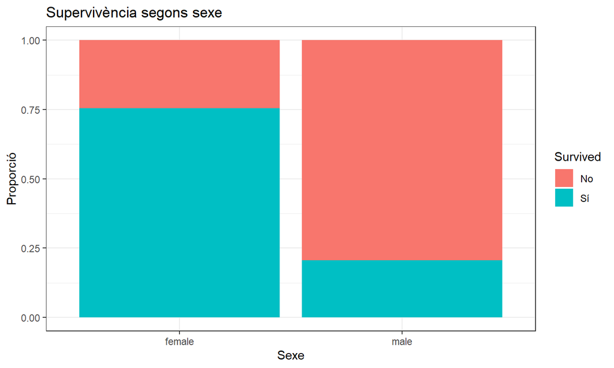

```r
ggplot(df, aes(x = Sex, fill = Survived)) +
  geom_bar(position = "fill") +
  labs(title = "Supervivència segons sexe", x = "Sexe", y = "Proporció")
```

## Chi-quadrat

```r
tab <- table(df$Sex, df$Survived)
chisq.test(tab)
```

```
##
##  Pearson's Chi-squared test with Yates' continuity correction
##
## data:  tab
## X-squared = 205.03, df = 1, p-value < 2.2e-16
```

## Exemple: hi ha més ozó en dies amb més temperatura?

Analitzem la relació entre temperatura i nivells d’ozó

Agafem dades de qualitat de l’aire:

```r
# Carreguem les dades de qualitat de l'aire
data(airquality)
```

## Gràfics

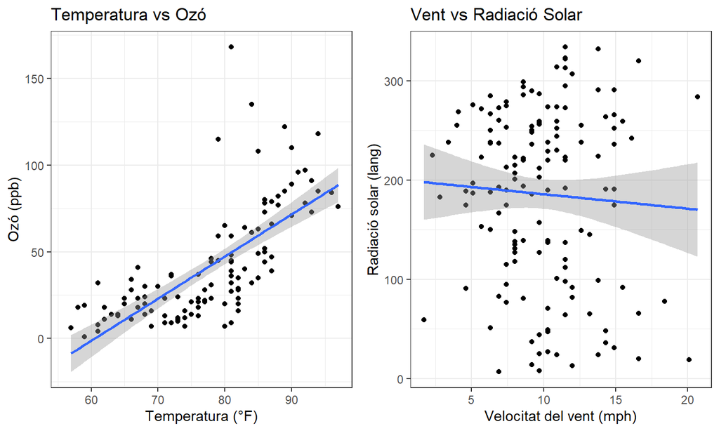

## Temperatura vs Ozó

```r
cor.test(~ Temp + Ozone, airquality)
```

```
##
##  Pearson's product-moment correlation
##
## data:  Temp and Ozone
## t = 10.418, df = 114, p-value < 2.2e-16
## alternative hypothesis: true correlation is not equal to 0
## 95 percent confidence interval:
##  0.5913340 0.7812111
## sample estimates:
##       cor
## 0.6983603
```

## Vent vs Solar.R

```r
cor.test(~ Wind + Solar.R, airquality, method = "spearman")
```

```
##
##  Spearman's rank correlation rho
##
## data:  Wind and Solar.R
## S = 519172, p-value = 0.9907
## alternative hypothesis: true rho is not equal to 0
## sample estimates:
##           rho
## -0.0009773325
```

## Models predictius

## Regressions

Amb els models predictius, no només comprovem una hipòtesi d’associació, si no que podem predir amb dades futures. Poden ser de molts tipus: nosaltres només veurem regressions lineals i logístiques.

### Regressions lineals

#### Univariants

\[ y = \beta_0 + \beta_1 * x \]

#### Multivariants

\[ y = \beta_0 + \beta_1 * x_1 + \beta_2 * x_2 + \beta_3 * x_3 + ... + \beta_n * x_n \]

On \(x\) són és variables independents (o predictores) i \(y\) la variable dependent (o predita).

## Regressions

Hem de trobar les \(\beta_1, ... \beta_n\) que ajustin el millor possibles els valors de les \(x\) amb la \(y\): **Ajust per mínims quadrats.**

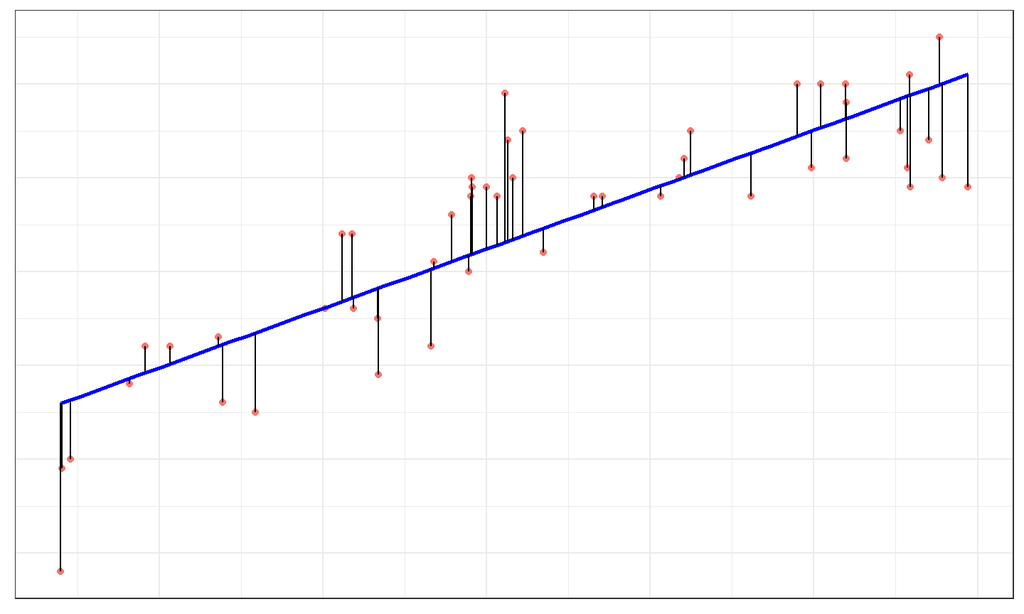

## Regressió lineal en R - Univariant

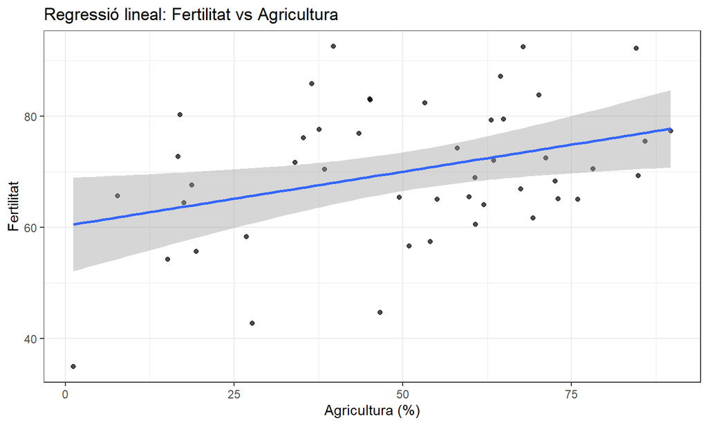

```r
# Carreguem les dades de fertilitat suïssa
data(swiss)

ggplot(swiss, aes(x = Agriculture, y = Fertility)) +
  geom_point(alpha = 0.7) +
  geom_smooth(method = "lm", se = TRUE) +
  labs(x = "Agricultura (%)", y = "Fertilitat",
       title = "Regressió lineal: Fertilitat vs Agricultura") +
  theme_bw()
```

## Regressió lineal en R - Univariant

```r
# Regressió univariant: Fertilitat vs Agricultura
model = lm(Fertility ~ Agriculture, data = swiss)
summary(model)
```

```
##
## Call:
## lm(formula = Fertility ~ Agriculture, data = swiss)
##
## Residuals:
##      Min       1Q   Median       3Q      Max
## -25.5374  -7.8685  -0.6362   9.0464  24.4858
##
## Coefficients:
##             Estimate Std. Error t value Pr(>|t|)
## (Intercept) 60.30438    4.25126  14.185   <2e-16 ***
## Agriculture  0.19420    0.07671   2.532   0.0149 *
## ---
## Signif. codes:  0 '***' 0.001 '**' 0.01 '*' 0.05 '.' 0.1 ' ' 1
##
## Residual standard error: 11.82 on 45 degrees of freedom
## Multiple R-squared:  0.1247, Adjusted R-squared:  0.1052
## F-statistic: 6.409 on 1 and 45 DF,  p-value: 0.01492
```

## Regressió lineal en R - Multivariant

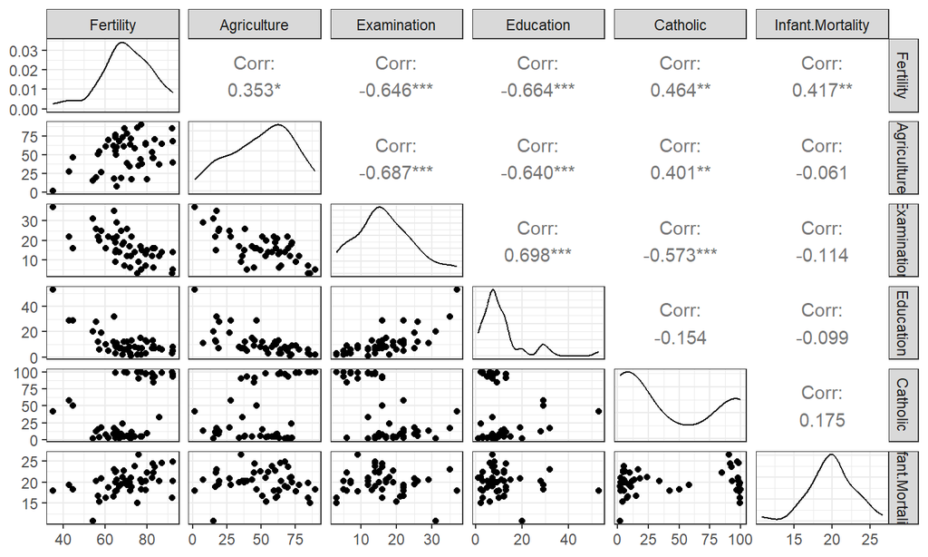

```r
library(GGally)
ggpairs(swiss)
```

## Regressió lineal en R - Multivariant

```r
# Regressió multivariant: Fertilitat vs totes les altres variables
model2 = lm(Fertility ~ ., data = swiss_clean)
summary(model2)
```

```
##
## Call:
## lm(formula = Fertility ~ ., data = swiss_clean)
##
## Residuals:
##      Min       1Q   Median       3Q      Max
## -1.22275 -0.42122  0.04029  0.32980  1.22652
##
## Coefficients:
##                    Estimate Std. Error t value Pr(>|t|)
## (Intercept)       5.162e-16  8.367e-02   0.000  1.00000
## Agriculture      -3.129e-01  1.278e-01  -2.448  0.01873 *
## Examination      -1.648e-01  1.621e-01  -1.016  0.31546
## Education        -6.704e-01  1.409e-01  -4.758 2.43e-05 ***
## Catholic          3.476e-01  1.177e-01   2.953  0.00519 **
## Infant.Mortality  2.511e-01  8.901e-02   2.822  0.00734 **
## ---
## Signif. codes:  0 '***' 0.001 '**' 0.01 '*' 0.05 '.' 0.1 ' ' 1
##
## Residual standard error: 0.5736 on 41 degrees of freedom
## Multiple R-squared:  0.7067, Adjusted R-squared:  0.671
## F-statistic: 19.76 on 5 and 41 DF,  p-value: 5.594e-10
```

## Gràfics de la regressió lineal

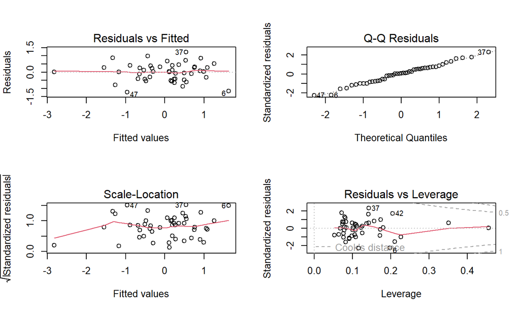

```r
# 3. Diagnòstics del model
par(mfrow = c(2, 2))
plot(model2)
```

## Resum

| Independent \ Dependent | Categòrica | Contínua |
| --- | --- | --- |
| Categòrica | \(\chi^2\); Test de Fisher | Test T; U de Mann Whitney; ANOVA |
| Contínua | Regressió logística | Correlació; regressió lineal |